title: ‘Batcave TERM Analysis’ author: ‘Albert’ date: ‘Aug 13, 2018’ output: html_document: df_print: paged word_document: default —

### Notes

Batcave  
Conditioned Area: 100000 square feet  
Time periods:

- Feb 01, 2014 - Dec 01, 2017 (Electric)
- Feb 01, 2014 - Dec 01, 2017 (Gas)

### Results

**Total EUI**: 48

| Stat | electric | gas |
| --- | --- | --- |
| EUI | 15.2 | 32.4 |
| Base Load | 14.3 | 9.1 |
| Cooling Base | 52.0 |  |
| Cooling Slope | 0.2 |  |
| Cooling UA | 2455.6 |  |
| Heating Base |  | 64.0 |
| Heating Slope |  | 2.0 |
| Heating UA |  | 22371.2 |

#### Model Parameter Bootstraps

Values for parameters arrived at resampling base data. We use this to understand the uncertainty in the numbers we calculated.

| Meter | Type | Parameter | 5% | 10% | 50% | 90% | 95% |
| --- | --- | --- | --- | --- | --- | --- | --- |
| electric | cooling | base | 48.0 | 48.6 | 51.6 | 54.6 | 55.4 |
| electric | cooling | slope | 0.2 | 0.2 | 0.2 | 0.3 | 0.3 |
| gas | heating | base | 60.6 | 61.6 | 64.4 | 67.8 | 70.2 |
| gas | heating | slope | 1.6 | 1.7 | 2.0 | 2.2 | 2.3 |

#### Gas meter:

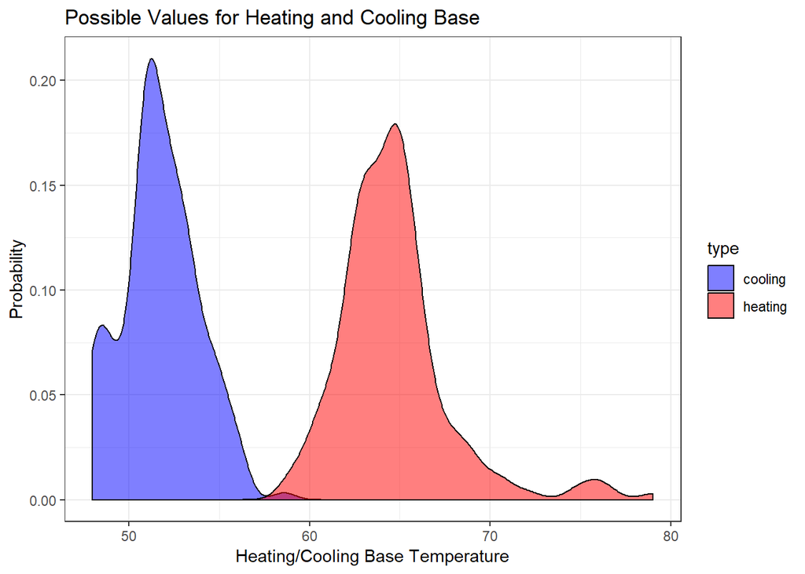

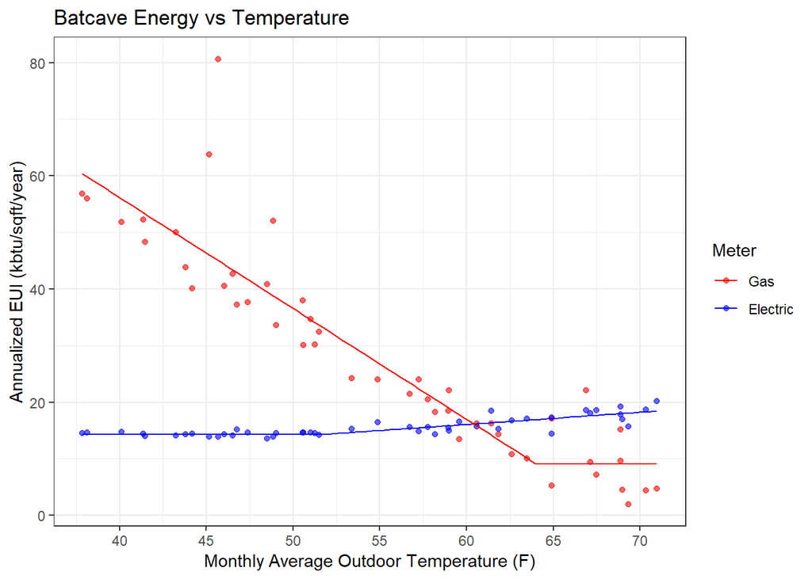

#### Heating/Cooling Fits

**Electric Cooling Fit**

tbal=52

r²=0.48

slope=0.21

coolingLoad=17

totalLoad=15.6

**Gas Heating Fit**

tbal=64

r²=0.78

slope=2.0

heatingLoad=35

totalLoad=28.7

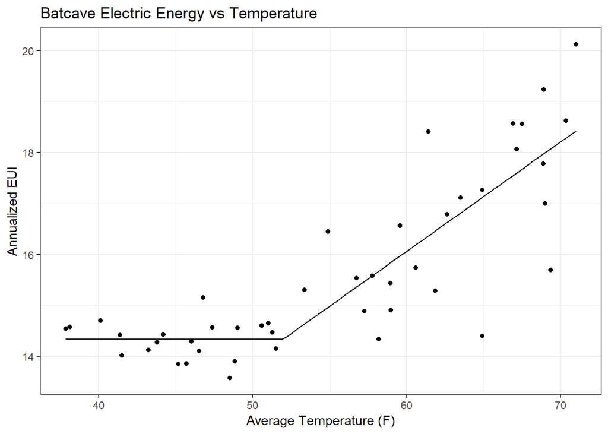

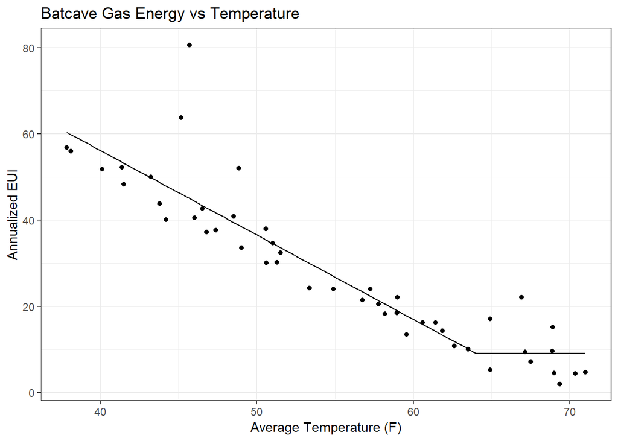

#### Residuals over time

The residual plot allows us to see if the model works better in a certain time period. If the dots don’t look to be randomly sprinkled around a horizontal line, you may want to rethink the time period you’re examining, as there may have been a change in the way the building operates. This is also a good way to identify billing cycles where something really weird happened (outliers).

I provide a short summary of what I see for for the audience here. For example:

Might be a gradual increase in electricity usage over time, but keep in mind that it is quite small to begin with. I don’t see anything of interest in the gas data.

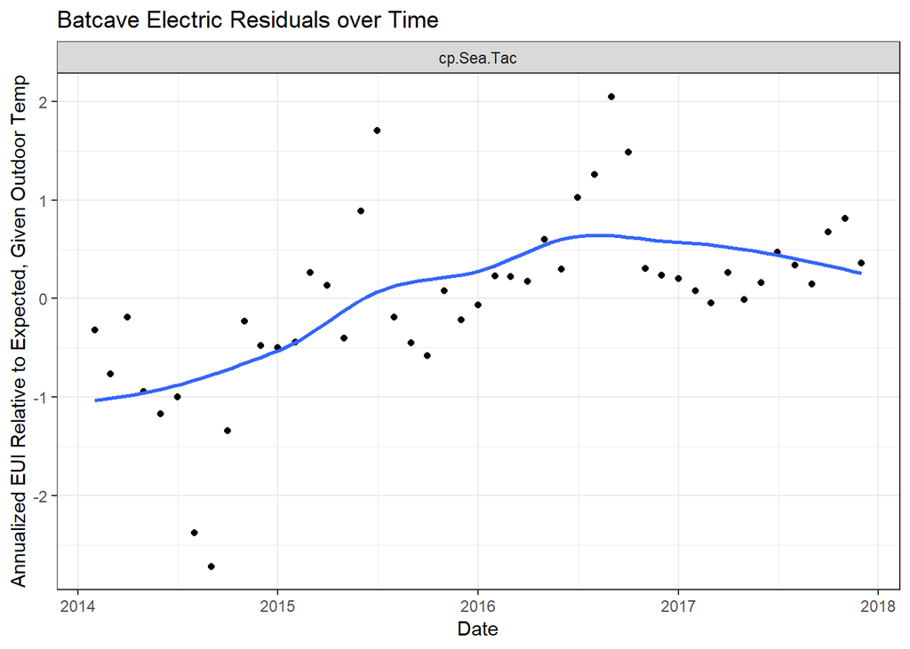

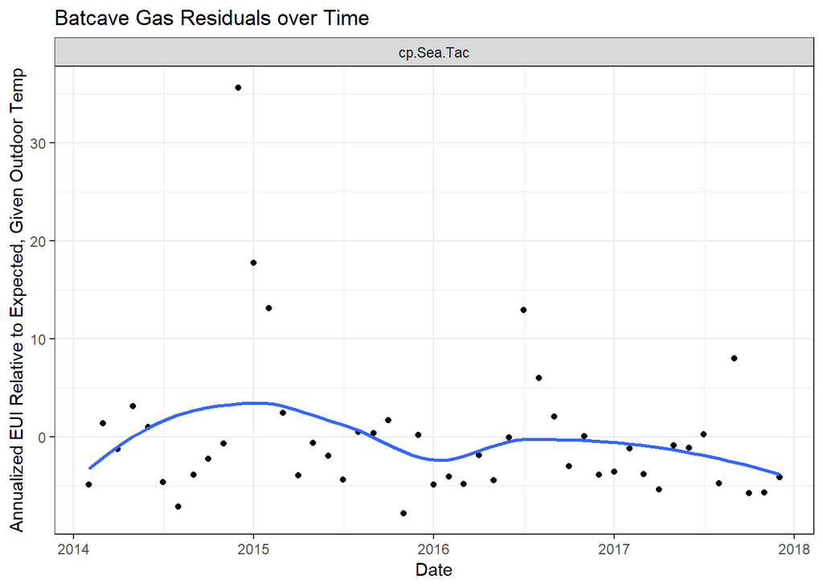